# Sampling and Descriptive Statistics

A **population** is the entire collection of objects or outcomes about which information is sought.

A **sample** is a subset of a population, containing the objects or outcomes that are actually observed.

A **simple random sample** of size n is a sample chosen by a method in which each collection of n population items is equally likely to make up the sample, just as in a lottery.

A **sample of convenience** is a sample that is obtained in some convenient way, and not drawn by a well-defined random method.

Two different samples from the same population will differ from each other as well. This phenomenon is known as **sampling variation**.

The items in a sample are **independent** if knowing the values of some of the items does not help to predict the values of the others.

Type of experiments:

1. Controlled experiment
2. Observational study

The two most commonly used summary statistics are the **sample mean** and the sample **standard deviation**.

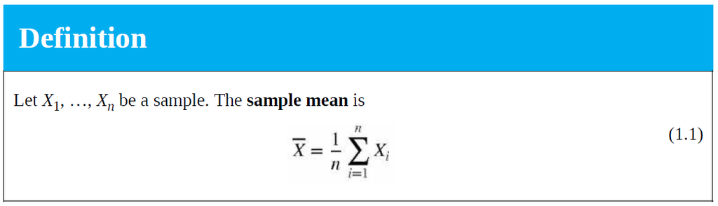

The standard deviation is a quantity that measures the degree of spread in a sample. Here are two lists of numbers: 28, 29, 30, 31, 32 and 10, 20, 30, 40, 50. Both lists have the same mean of 30.

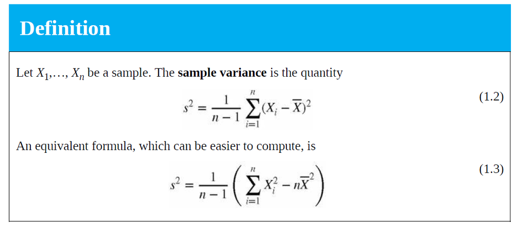

While the sample variance is an important quantity, it has a serious drawback as a measure of spread. Its units are not the same as the units of the sample values; instead they are the squared units. To obtain a measure of spread whose units are the same as those of the sample values, we simply take the square root of the variance. This quantity is known as the sample standard deviation.

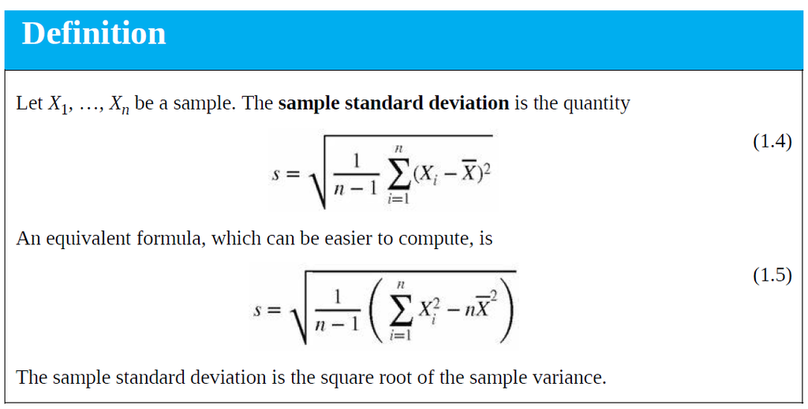

It is natural to wonder why the sum of the squared deviations is divided by n − 1 rather than n. The purpose in computing the sample standard deviation is to estimate the amount of spread in the population from which the sample was drawn. Ideally, therefore, we would compute deviations from the mean of all the items in the population, rather than the deviations from the sample mean. However, the population mean is in general unknown, so the sample mean is used in its place. It is a mathematical fact that the deviations around the sample mean tend to be a bit smaller than the deviations around the population mean and that dividing by n − 1 rather than n provides exactly the right correction.

The median, like the mean, is a measure of center. To compute the median of a sample, order the values from smallest to largest. The sample median is the middle number. If the sample size is an even number, it is customary to take the sample median to be the average of the two middle numbers.

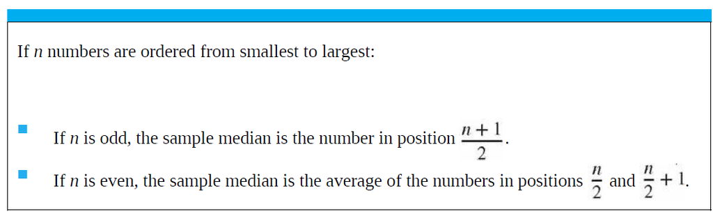

trimmed mean is a measure of center that is designed to be unaffected by outliers. The trimmed mean is computed by arranging the sample values in order, “trimming” an equal number of them from each end, and computing the mean of those remaining. If p% of the data are trimmed from each end, the resulting trimmed mean is called the “p% trimmed mean.”

Sometimes a sample may contain a few points that are much larger or smaller than the rest. Such points are called outliers. Sometimes outliers result from data entry errors; for example, a misplaced decimal point can result in a value that is an order of magnitude different from the rest. Outliers should always be scrutinized, and any outlier that is found to result from an error should be corrected or deleted. Not all outliers are errors. Sometimes a population may contain a few values that are much different from the rest, and the outliers in the sample reflect this fact.

A statistic whose value does not change much when an outlier is added to or removed from a sample is said to be **resistant**.

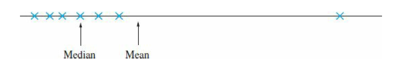

The median divides the sample in half.Quartiles divide it as nearly as possible into quarters.

With categorical data, each sample item is assigned a category rather than a quantitative value. But to work with categorical data, numerical summaries are needed. The two most commonly used ones are the frequencies and the sample proportions (sometimes called relative frequencies).The frequency for a given category is simply the number of sample items that fall into that category. The sample proportion is the frequency divided by the sample size.

There is no hard-and-fast rule as to how to choose the endpoints of the class intervals. In general, it is good to have more intervals rather than fewer, but it is also good to have large numbers of sample points in the intervals. Striking the proper balance is a matter of judgment and of trial and error. When the number of observations n is large (several hundred or more), some have suggested that reasonable starting points for the number of classes may be log2 n or 2n1/3. When the number of observations is smaller, more classes than these are often needed.

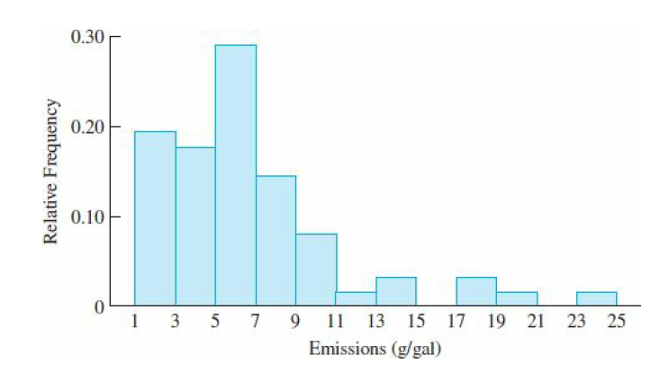

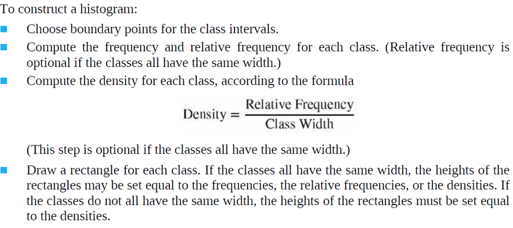

```
      one  two
0       4   10
1       1    7
2       2    5
3       1    7
4       5    9
...   ...  ...
5995    3    6
5996    6    8
5997    6   12
5998    3    9
5999    1    4

[6000 rows x 2 columns]
```

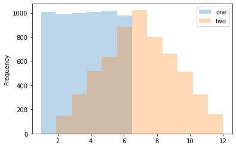

```python
import pandas as pd
import numpy as np
df = pd.DataFrame(
    np.random.randint(1, 7, 6000),
    columns = ['one'])
df['two'] = df['one'] + np.random.randint(1, 7, 6000)
print(df)
ax = df.plot(kind='hist',bins=12,alpha=0.3)
```

A histogram is perfectly symmetric if its right half is a mirror image of its left half. Histograms that are not symmetric are referred to as skewed.

A histogram is unimodal if it has only one peak, or mode, and bimodal if it has two clearly distinct modes.Some cases, a bimodal histogram indicates that the sample can be divided into two subsamples that differ from each other in some scientifically important way.

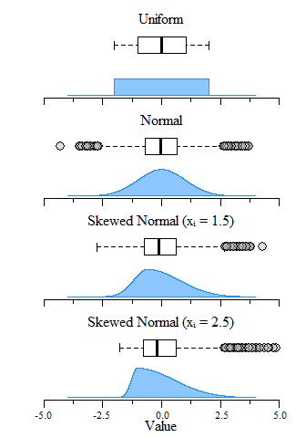

A boxplot is a graphic that presents the median, the first and third quartiles, and any outliers that are present in a sample. Boxplots are easy to understand, but there is a bit of terminology that goes with them. The interquartile range is the difference between the third quartile and the first quartile. Note that since 75% of the data is less than the third quartile, and 25% of the data is less than the first quartile, it follows that 50%, or half, of the data are between the first and third quartiles. The interquartile range is therefore the distance needed to span the middle half of the data.

[figure not shown]

We have defined outliers as points that are unusually large or small. If IQR represents the interquartile range, then for the purpose of drawing boxplots, any point that is more than 1.5 IQR above the third quartile, or more than 1.5 IQR below the first quartile, is considered an outlier.

Some texts define a point that is more than 3 IQR from the first or third quartile as an extreme outlier.

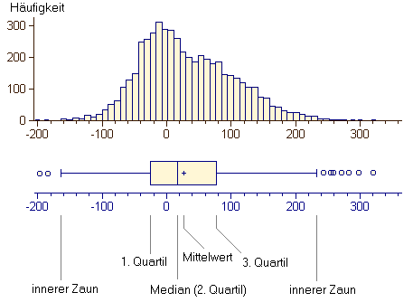

# Propagation of Error

Any measuring procedure contains error. As a result, measured values generally differ somewhat from the true values that are being measured. When a calculation is performed with measurements, the errors in the measurements produce an error in the calculated value. We say that the error is propagated from the measurements to the calculated value.

1. The bias is the part of the error that is the same for every measurement.
2. The random error, on the other hand, varies from measurement to measurement, and averages out to zero in the long run.

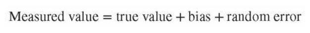

We are interested in two aspects of the measuring process. First is its accuracy. The accuracy is determined by the bias, which is the difference between the mean measurement μ and the true value being measured. The smaller the bias, the more accurate the measuring process. If the mean μ is equal to the true value, so that the bias is 0, the measuring process is said to be unbiased. The other aspect of the measuring process that is of interest is the precision. Precision refers to the degree to which repeated measurements of the same quantity tend to agree with each other. If repeated measurements come out nearly the same every time, the precision is high. If they are widely spread out, the precision is low.

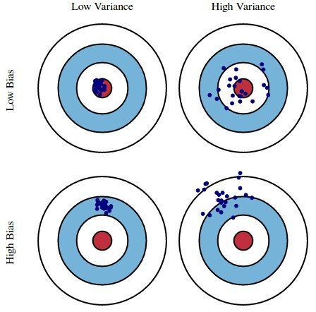

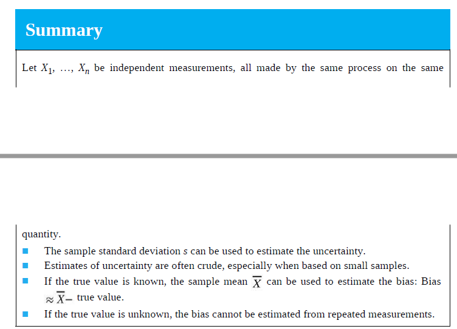

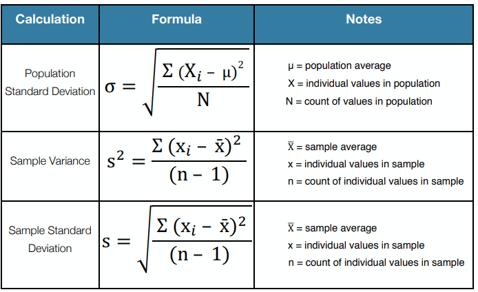